# Replication of Experiment 4 in ‘’What Predicts Children’s Fixed and Growth Intelligence Mindsets? Not Their Parents’ View of Intelligence but Their Parents’ View of Failure’’ by Haimovitz and Dweck (2

#### Manipulation Check Part 2 (Main Manipulation Check): Did the parents in the failure-is-debilitating condition report more of a failure-is-debilitating mindset than the parents in the failure-is-enhancing condition?

##### Original Study Result

> “Indeed, the manipulation seemed to shift parents’ mind-sets, t(124) = 2.53, p = 0.013: Parents in the failure-is-enhancing condition reported more of a failure-is-enhancing mind-set than did parents in the failure-is-debilitating condition.”

```r
# get relevant manipulation survey data and compute composite
data_manip_2 <- data_long |>
  filter(measure == "failure") |>
  filter(!is.na(value_w_rs)) |>
  group_by(prolific_id, condition) |>
  summarise(composite_f = mean(value_w_rs))
```

##### T-Test

```r
# make a dataframe for the FID and FIE conditions
data_manip_2_fid <- data_manip_2 |>
  filter(condition == "debilitating")
data_manip_2_fie <- data_manip_2 |>
  filter(condition == "enhancing")

# T-Test
data_manip_2_ttest <- t.test(data_manip_2_fid$composite_f, data_manip_2_fie$composite_f, alternative = "two.sided", var.equal = FALSE)
data_manip_2_ttest
```

```
##
##  Welch Two Sample t-test
##
## data:  data_manip_2_fid$composite_f and data_manip_2_fie$composite_f
## t = 4.5965, df = 111.64, p-value = 1.138e-05
## alternative hypothesis: true difference in means is not equal to 0
## 95 percent confidence interval:
##  0.4006928 1.0079029
## sample estimates:
## mean of x mean of y
##  3.186441  2.482143
```

##### Figure

```r
# compute relevant information to generate figure
data_manip_2_fig <- data_manip_2 |>
  group_by(condition) |>
  summarise(
    count = n(),
    mean_f = mean(composite_f, na.rm = TRUE),
    sd_f = sd(composite_f, na.rm = TRUE),
    sem_f = sd_f / sqrt(count)
  )

head(data_manip_2_fig)
```

```
## # A tibble: 2 × 5
##   condition    count mean_f  sd_f sem_f
##   <chr>        <int>  <dbl> <dbl> <dbl>
## 1 debilitating    59   3.19 0.887 0.116
## 2 enhancing       56   2.48 0.753 0.101
```

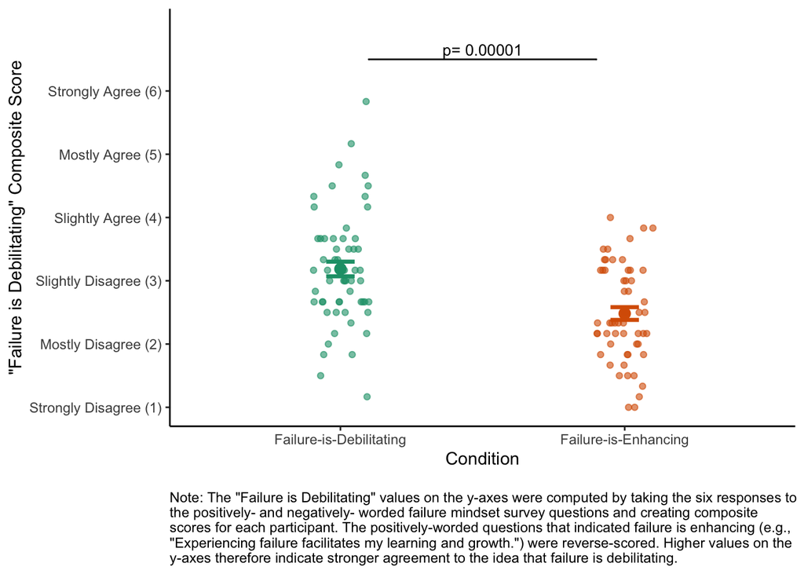

```r
# generate figure
fig_manip_2 <- ggplot(data_manip_2_fig, aes(x=condition, y=mean_f, color=condition)) +
  geom_point(size=3) +
  geom_errorbar(aes(ymin=mean_f-sem_f,
                    ymax=mean_f+sem_f),
                width=0.1, size=1.2) +
  geom_jitter(data=data_manip_2,
              aes(x=condition, y=composite_f),
              width = 0.1, height = 0, alpha=0.6) +
  scale_color_brewer(palette = "Dark2") +
  scale_x_discrete("Condition",
                   labels=c("debilitating" = "Failure-is-Debilitating",
                            "enhancing" = "Failure-is-Enhancing")) +
  ylab('"Failure is Debilitating" Composite Score') +
  expand_limits(y=c(0,7)) +
  coord_cartesian(ylim = c(1, 7)) +
  scale_y_continuous(breaks = c(1:6),
                     # label them with names
                     labels = c("Strongly Disagree (1)", "Mostly Disagree (2)", "Slightly Disagree (3)",
                                "Slightly Agree (4)", "Mostly Agree (5)", "Strongly Agree (6)")) +
  geom_signif(
    y_position = c(6.5),
    xmin = c(1.1), xmax = c(1.9),
    annotation = c(paste("p=", format(round(data_manip_2_ttest$p.value, digits = 5), scientific = FALSE))),
    tip_length = 0.0,
    textsize = 3.5,
    color = "black") +
  labs(caption = '\nNote: The "Failure is Debilitating" values on the y-axes were computed by taking the six responses to \nthe positively- and negatively- worded failure mindset survey questions and creating composite \nscores for each participant. The positively-worded questions that indicated failure is enhancing (e.g., \n"Experiencing failure facilitates my learning and growth.") were reverse-scored. Higher values on the \ny-axes therefore indicate stronger agreement to the idea that failure is debilitating.') +
  theme_classic() +
  theme(legend.position = "none",
        plot.caption = element_text(hjust = 0))

fig_manip_2
```

##### Manipulation Check Follow-Up Analyses

The analyses above reveals a high level of variability in failure mindset even within the conditions. I was therefore curious to ask the following question:

**Across conditions, is it possible that parents who more strongly believe failure is debilitating react to failure scenarios in 1) less learning-oriented ways and 2) more performance-oriented ways, compared to parents who disagree that failure is debilitating?**

```r
#Combine failure mindset composite scores with learning-oriented and performance-oriented responses
coded_lor_por <- metadata |>
  select(c("prolific_id", "coded_por", "coded_lor", "debrief_q2"))
data_manip_change_followup <- merge(coded_lor_por, data_manip_2, by="prolific_id")

#Linear regressions
summary(lm(data_manip_change_followup$coded_lor ~ data_manip_change_followup$composite_f))
```

```
##
## Call:
## lm(formula = data_manip_change_followup$coded_lor ~ data_manip_change_followup$composite_f)
##
## Residuals:
##     Min      1Q  Median      3Q     Max
## -1.9563 -0.6123 -0.1439  0.5440  4.1062
##
## Coefficients:
##                                        Estimate Std. Error t value Pr(>|t|)
## (Intercept)                              2.5192     0.3103   8.119 6.43e-13 ***
## data_manip_change_followup$composite_f  -0.3752     0.1041  -3.604 0.000468 ***
## ---
## Signif. codes:  0 '***' 0.001 '**' 0.01 '*' 0.05 '.' 0.1 ' ' 1
##
## Residual standard error: 0.994 on 113 degrees of freedom
## Multiple R-squared:  0.1031, Adjusted R-squared:  0.09513
## F-statistic: 12.99 on 1 and 113 DF,  p-value: 0.0004682
```

```r
summary(lm(data_manip_change_followup$coded_por ~ data_manip_change_followup$composite_f))
```

```
##
## Call:
## lm(formula = data_manip_change_followup$coded_por ~ data_manip_change_followup$composite_f)
##
## Residuals:
##     Min      1Q  Median      3Q     Max
## -0.7731 -0.5377 -0.3965  0.4388  2.5094
##
## Coefficients:
##                                        Estimate Std. Error t value Pr(>|t|)
## (Intercept)                             0.13751    0.21727   0.633   0.5281
## data_manip_change_followup$composite_f  0.14124    0.07292   1.937   0.0553 .
## ---
## Signif. codes:  0 '***' 0.001 '**' 0.01 '*' 0.05 '.' 0.1 ' ' 1
##
## Residual standard error: 0.6961 on 113 degrees of freedom
## Multiple R-squared:  0.03213,    Adjusted R-squared:  0.02357
## F-statistic: 3.752 on 1 and 113 DF,  p-value: 0.05525
```

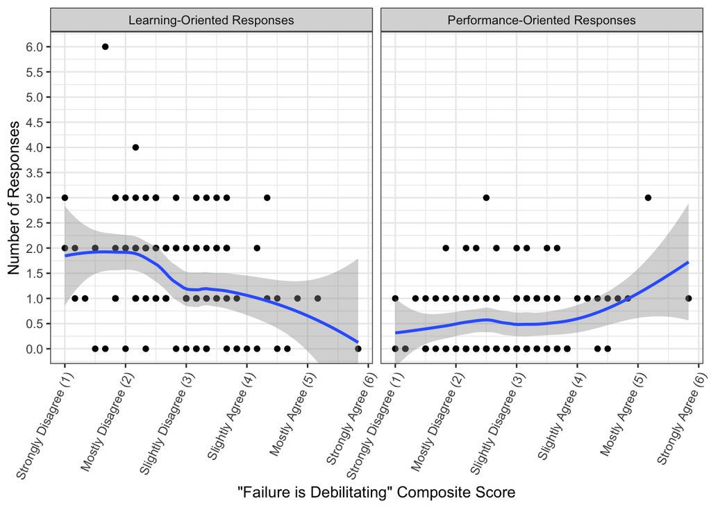

```r
#generate figure
data_manip_change_followup_fig_1 <- data_manip_change_followup |>
  pivot_longer(coded_por:coded_lor,
               names_to="code_type",
               values_to="score")

fig_1_manip_change_followup <- ggplot(data=data_manip_change_followup_fig_1, aes(x=composite_f, y=score)) +
  facet_wrap(~code_type,
             labeller = labeller(code_type = c("coded_lor" = "Learning-Oriented Responses",
                                               "coded_por" = "Performance-Oriented Responses"))) +
  geom_point() +
  geom_smooth() +
  xlab('"Failure is Debilitating" Composite Score') +
  ylab("Number of Responses") +
  scale_x_continuous(breaks = c(1:6),
                     # label them with names
                     labels = c("Strongly Disagree (1)", "Mostly Disagree (2)", "Slightly Disagree (3)",
                                "Slightly Agree (4)", "Mostly Agree (5)", "Strongly Agree (6)"),
                     guide=guide_axis(angle=65)) +
  scale_y_continuous(breaks=seq(0,6,0.5)) +
  coord_cartesian(ylim = c(0, 6)) +
  theme_bw()
fig_1_manip_change_followup
```

#### Funnel Debrief Analysis

##### Debrief Question: Are you familiar with the term failure mindset, or growth/fixed mindset?

```r
kable(table(metadata$debrief_q2), col.names = c("Answer", "N"))
```

| Answer | N |
| --- | --- |
| Yes | 44 |
| No | 48 |
| Not sure | 23 |
| NA | 0 |

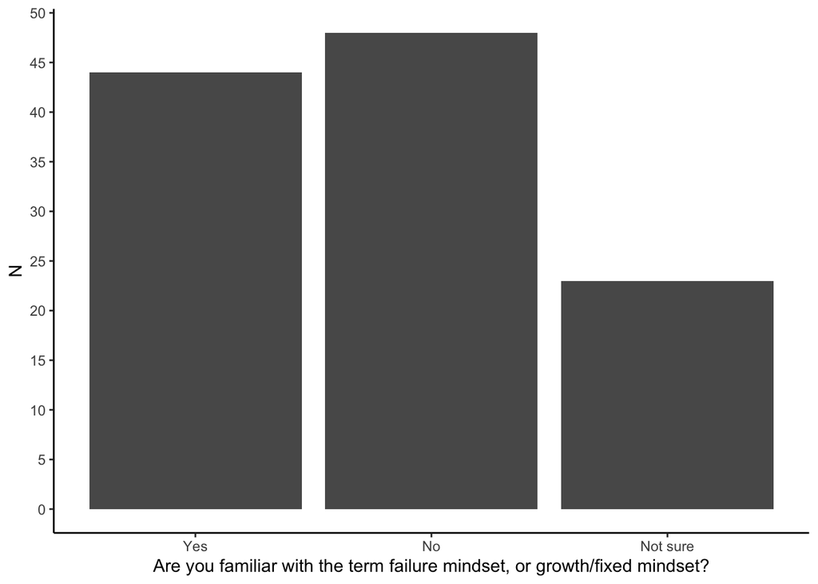

```r
fig_debrief2 <- ggplot(metadata, aes(x=debrief_q2)) +
  geom_bar() +
  xlab("Are you familiar with the term failure mindset, or growth/fixed mindset?") +
  ylab("N") +
  scale_y_continuous(breaks=seq(0,50,5)) +
  theme_classic()
fig_debrief2
```

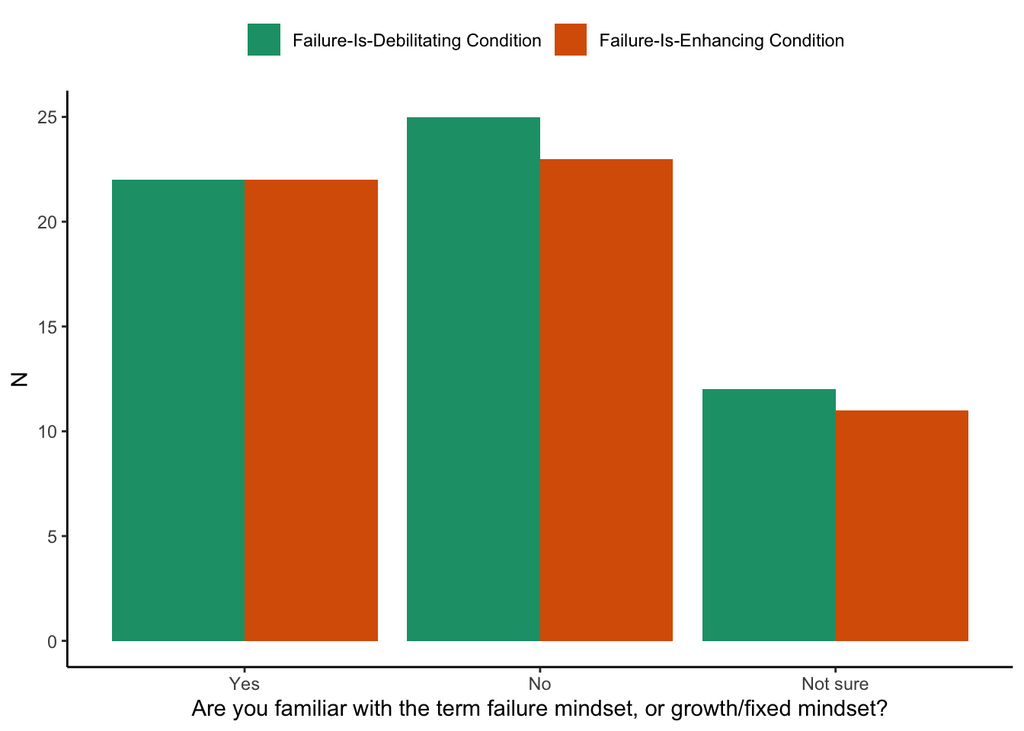

```r
fig_debrief2_condition <- ggplot(metadata, aes(x=debrief_q2, fill=condition)) +
  geom_bar(position="dodge") +
  xlab("Are you familiar with the term failure mindset, or growth/fixed mindset?") +
  ylab("N") +
  scale_y_continuous(breaks=seq(0,25,5)) +
  theme_classic() +
  theme(legend.position="top",
        legend.title = element_blank()) +
  scale_fill_brewer(labels=c("Failure-Is-Debilitating Condition",
                               "Failure-Is-Enhancing Condition"),
                    palette = "Dark2")

fig_debrief2_condition
```

##### Debrief Question: Do you think your own mindset impacts your child(ren)’s mindset?

```r
data_debrief3 <- metadata |>
  filter(debrief_q2 == "Yes")
kable(table(data_debrief3$debrief_q3), col.names = c("Answer", "N"))
```

| Answer | N |
| --- | --- |
| Yes | 42 |
| No | 1 |
| Not sure | 1 |
| NA | 0 |

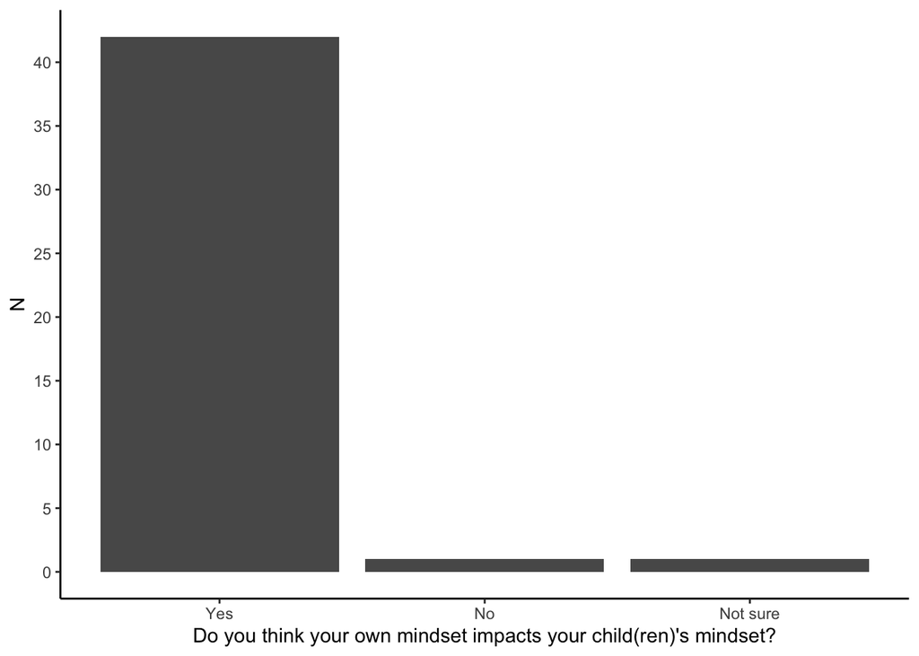

```r
fig_debrief3 <- ggplot(data_debrief3, aes(x=debrief_q3)) +
  geom_bar() +
  xlab("Do you think your own mindset impacts your child(ren)'s mindset?") +
  ylab("N") +
  scale_y_continuous(breaks=seq(0,45,5)) +
  theme_classic()
fig_debrief3
```

##### Did parents’ knowledge of mindset research have any effect on their performance-oriented and learning-oriented responses?

```r
data_funneldebrief <- metadata |>
  pivot_longer(coded_por:coded_lor,
               names_to = "code_type",
               values_to = "response")

data_funneldebrief_stats <- data_funneldebrief |>
  group_by(debrief_q2, code_type) |>
  summarise(count = n(),
            mean = mean(response, na.rm = TRUE),
            sd = sd(response, na.rm = TRUE),
            sem = sd / sqrt(count),)
data_funneldebrief_cond_stats <- data_funneldebrief |>
  group_by(debrief_q2, condition, code_type) |>
  summarise(count = n(),
            mean = mean(response, na.rm = TRUE),
            sd = sd(response, na.rm = TRUE),
            sem = sd / sqrt(count),)
```

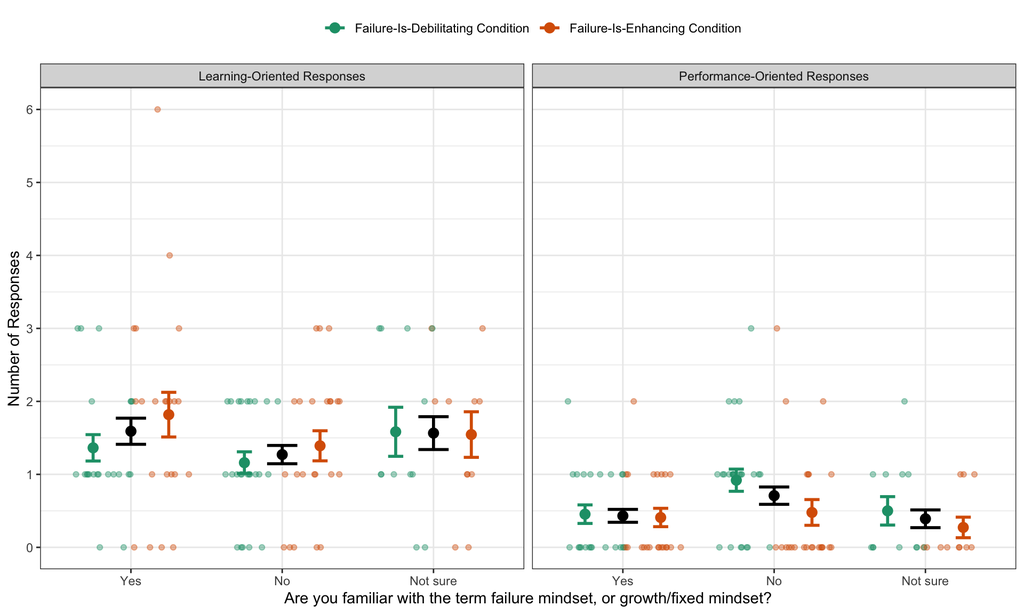

```r
fig_funneldebrief <- ggplot(data=data_funneldebrief_stats, aes(x=debrief_q2, y=mean)) +
  facet_wrap(~code_type,
             labeller = labeller(code_type = c("coded_lor" = "Learning-Oriented Responses",
                                               "coded_por" = "Performance-Oriented Responses"))) +
  geom_point(colour="black", size=3) +
  geom_errorbar(aes(ymin=mean-sem, ymax=mean+sem), width=.2, colour="black", size=1) +
  geom_jitter(data = data_funneldebrief, aes(x = debrief_q2, y = response, color=condition), alpha=0.4,
              position = position_jitterdodge()) +
  geom_point(data=data_funneldebrief_cond_stats, aes(x=debrief_q2, y=mean, color=condition), size=3,
             position=position_dodge(width=1)) +
  geom_errorbar(data=data_funneldebrief_cond_stats, aes(ymin=mean-sem, ymax=mean+sem, color=condition),
                width=.2, size=1,
                position=position_dodge(width=1)) +
  scale_color_brewer(labels=c("Failure-Is-Debilitating Condition",
                              "Failure-Is-Enhancing Condition"),
                     palette = "Dark2") +
  xlab("Are you familiar with the term failure mindset, or growth/fixed mindset?") +
  ylab("Number of Responses") +
  scale_y_continuous(breaks=seq(0,6,1)) +
  theme_bw() +
  theme(legend.position="top",
        legend.title = element_blank())
fig_funneldebrief
```

##### Is it possible that parents’ knowledge of mindset research affected their response to the failure mindset survey used in the manipulation check?

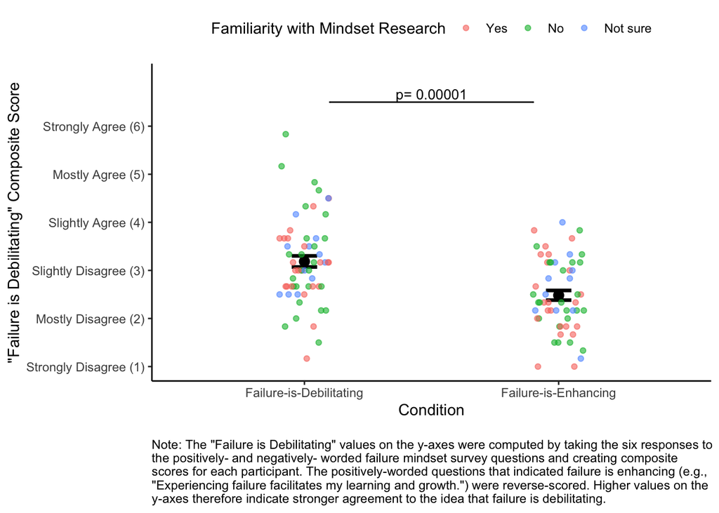

```r
debrief_q2 <- metadata |>
  select(c("prolific_id", "debrief_q2"))
data_manip_2_w_debrief <- merge(debrief_q2, data_manip_2, by="prolific_id")

fig_manip_2_w_debrief <- ggplot(data_manip_2_fig, aes(x=condition, y=mean_f)) +
  geom_point(size=3) +
  geom_errorbar(aes(ymin=mean_f-sem_f,
                    ymax=mean_f+sem_f),
                width=0.1, size=1.2) +
  geom_jitter(data=data_manip_2_w_debrief,
              aes(x=condition, y=composite_f, color=debrief_q2),
              width = 0.1, height = 0, alpha=0.6) +
  scale_x_discrete("Condition",
                   labels=c("debilitating" = "Failure-is-Debilitating",
                            "enhancing" = "Failure-is-Enhancing")) +
  ylab('"Failure is Debilitating" Composite Score') +
  expand_limits(y=c(0,7)) +
  coord_cartesian(ylim = c(1, 7)) +
  scale_y_continuous(breaks = c(1:6),
                     # label them with names
                     labels = c("Strongly Disagree (1)", "Mostly Disagree (2)", "Slightly Disagree (3)",
                                "Slightly Agree (4)", "Mostly Agree (5)", "Strongly Agree (6)")) +
  geom_signif(
    y_position = c(6.5),
    xmin = c(1.1), xmax = c(1.9),
    annotation = c(paste("p=", format(round(data_manip_2_ttest$p.value, digits = 5), scientific = FALSE))),
    tip_length = 0.0,
    textsize = 3.5,
    color = "black") +
  labs(caption = '\nNote: The "Failure is Debilitating" values on the y-axes were computed by taking the six responses to \nthe positively- and negatively- worded failure mindset survey questions and creating composite \nscores for each participant. The positively-worded questions that indicated failure is enhancing (e.g., \n"Experiencing failure facilitates my learning and growth.") were reverse-scored. Higher values on the \ny-axes therefore indicate stronger agreement to the idea that failure is debilitating.') +
  theme_classic() +
  theme(legend.position = "top",
        plot.caption = element_text(hjust = 0)) +
  scale_color_discrete("Familiarity with Mindset Research")

fig_manip_2_w_debrief
```

## Discussion

### Summary of Replication Attempt

The key analysis of interest was an unpaired, two-tailed t test comparing performance-oriented responses between the failure-is-debilitating condition and failure-is-enhancing condition. The original authors reported the following result:

> “Parents who were induced to hold a failure-is-debilitating mind-set were more likely to react with concerns about their child’s performance and lack of ability, t(131) = 3.246, p < .001, ηp2 = .075 … compared with those who were induced to hold a failure-is-enhancing mind-set.”

The replication study showed similar trends to this original finding. The effect was not as large and there was no statistical difference in the number of performance-oriented responses between the two conditions, t(113) = -1.9291, p = 0.0562, ηp2 = .031. However, I think my replication was rather successful, given that my sample size was smaller.

### Commentary

The exploratory analysis comparing the difference in the learning-oriented responses between the two conditions was promising. Although the difference was not significant, the finding showed similar trends to the original study.

The exploratory analyses also provided some insight as to why my results showed less of a difference between the two conditions, compared to the original study.

1. In line with the original study, each of the conditions’ average response to the biased surveys differed from the midpoint and was above it, indicating agreement. However, plotting individual participants’ responses to the biased survey revealed that there were a lot of parents in the failure-is-debilitating condition who were below the midpoint and actually disagreed with the biased survey questions. Furthermore, the average response within the failure-is-debilitating condition was slightly higher in the original study, indicating that there was slightly more agreement to the failure-is-debilitating statements in the original study.
2. In line with the original study, parents in the failure-is-debilitating condition reported more of a failure-is-debilitating mindset at the end of the paradigm. However, there was a lot of individual variability especially within the failure-is-debilitating group. Furthermore, the average numerical value for failure mindset was 3.19, which corresponds to the answer choice: “slightly disagree.” In other words, those in the failure-is-debilitating condition reported that on average, they “slightly disagree” to the idea that failure is debilitating.
3. Further analyses on the funnel debrief question also hint at the possibility that past knowledge of mindset research may have affected the results.

Overall, these exploratory analyses provide some reason to believe that many parents seem to inherently believe that failure is enhancing, and that it can be hard to induce a different belief. This phenomenon may especially be prevalent more recently, given that the mindset literature has become overly popularized.

More generally, I learned that there is a level of subjectivity in coding open-ended responses, making these types of studies hard to replicate. The authors provided a detailed coding scheme, which was crucial in helping me code the responses. In addition to documenting detailed procedures around coding, sharing the raw response data and the scores could be helpful as well. This information would be especially useful in providing more detailed examples of how the raw responses were coded.

Taken together, the replication study was rather successful. Coding open-ended responses can be subjective and prone to error. Furthermore, the exploratory analyses showed that failure mindsets were hard to induce in the first place. Despite these factors that went against successfully replicating my study, I was able to find promising, marginal differences between the two conditions.